# ETC5512: Instructions for Lab 8

Emi Tanaka

Week 8

**Please do Preparation *before* the tutorial!**

## 🎯 Objectives

In this tutorial, you will learn to

- interrogate your data by studying summary statistics
- calculate uncertainties of point estimates using bootstrap
- conduct a simple simulation study
- conduct visual inference

## 🔧 Preparation

1. **Set up your project folder**

   Similar to week 7 lab, prepare a project calling it say `etc5512-week08` with folders `data` and `analysis` in the project root directory. While you don’t have to follow the structure strictly, it’s a good habit to maintain a project workflow.
2. **Getting the PISA data**
   - To get the dataset go to http://www.oecd.org/pisa/data/2018database/
   - Then go under SPSS (TM) Data Files (compressed)
   - And click on Student questionnaire data file
   - [OPTIONAL] The downloaded file should be called `CY07_STU_QQQ.zip` is about 494MB. Unzip and place the extracted file `CY07_MSU_STU_QQQ.sav` into the `data` folder.
   - Download a smaller version of this data set (about 60MB) [here](https://github.com/numbats/wcd/raw/master/data/pisa2018.rds) and place it into a `data` folder.
3. **Install `haven` and `nullabor` R-packages**

```r
install.packages("haven", "nullabor")
```

4. **Check your project structure**

   Your project structure should look like below.

```
etc5512-week08
├── README.md
├── analysis
│   └── exercise.Rmd
├── data
│   ├── CY07_MSU_STU_QQQ.sav [OPTIONAL]
│   └── pisa2018.rds
└── etc5512-week08.Rproj
```

- *Troubleshooting*: if you have an issue downloading datasets, installing software, running commands, and so on then you can make a permanent copy of [this RStudio Cloud project](https://rstudio.cloud/project/1255305) instead.

## 🏫 Exercise 8A

**Interrogate the PISA data**

Load the PISA 2018 data in R. You may like to use the smaller data provided in `rds` format instead even if you have the `sav` format one. The `sav` file is over 1GB and so it does take a while to load the data into R. Note however that there are fast ways to import large `csv` files in R (e.g. using `data.table` or `vroom`).

```r
library(tidyverse)
library(haven)
pisa2018 <- readRDS(here::here("data", "pisa2018.rds"))
# OR
# pisa2018 <- read_sav(here::here("data", "CY07_MSU_STU_QQQ.sav"))
```

1. How many students participated by each country/region?
2. Draw a dot plot with mean differences of math scores (based on `PV1MATH`) by gender for each country with error bars based on 5% and 95% quantiles from 100 bootstrap mean differences.
3. How many students conducted the test with `BOOKID` as Form 1-12 or 67-78 (i.e. the number of students who sat for a test that included a maths component) by each country?
4. Draw the same plot as b. but just based on math scores for students whose test did include a maths component.

## 👩‍🎓 Exercise 8B

**What about gender gap in reading and science?**

Draw the same graph as 8A b. using `PV1READ` and `PV1SCIE`. What do you notice?

## 👨‍🏫 Exercise 8C

**Make better plots**

This question is based on a working book by [Hofmann et al.](https://github.com/heike/data-technologies/blob/master/11-case-study-education.Rmd).

- A problem with the dot plot is that the mean difference axis uses negative numbers, whenever the boys average is higher than the girls. A more accurate reflection on the gender difference would be to use only positive numbers, and label right of 0 to be “girls higher” and left of 0 to be “boys higher”.
- It could also be useful to have a finer resolution of grid lines on the mean difference.
- 🔧 Improve the mean difference axis, so that it has positive numbers only and enhanced labels, and ticks at increments of 5 points.

Add error bars based on 5% and 95% quantiles from 100 bootstrap mean differences. Color the error bar as purple for countries where the girls are significantly performing better than boys and as blue for vice versa.

In other words, your plot should look like below.

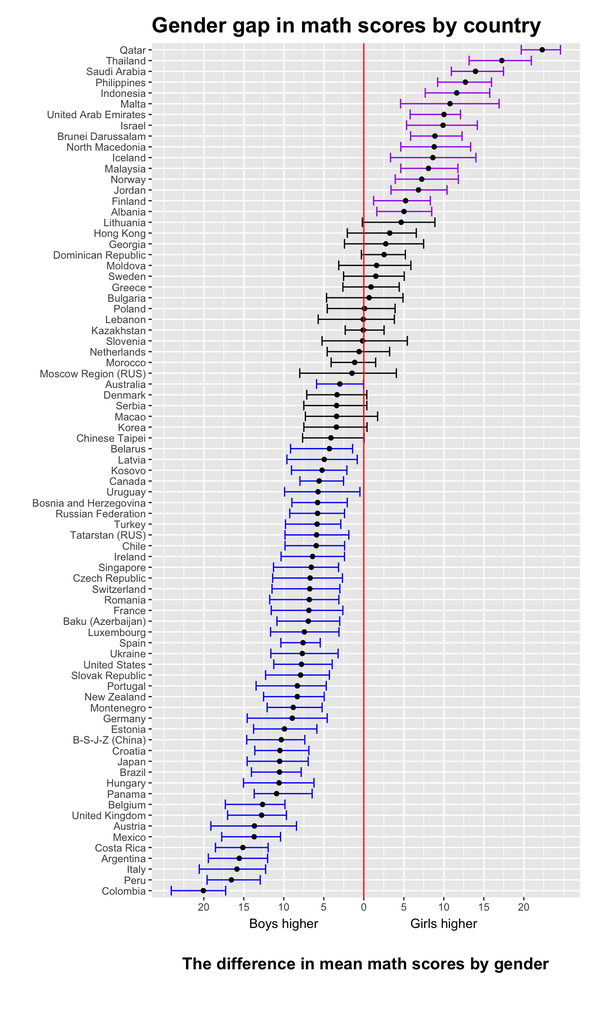

## 👩‍🎓 Exercise 8D

**Known truths: simulated data**

Mathematically, the data generating process for the response is as follows:

$$\begin{eqnarray*}
\color{blue}{y_{i1}} &=& \color{red}{\beta_0} + \color{red}{\beta_1}\color{blue}{x_i} + e_{i2},\\[1mm]
\color{blue}{\qquad y_{i2}} &=& \color{red}{\gamma_1}\color{blue}{z_{i1}} + \color{red}{\gamma_2}\color{blue}{z_{i2}} + \color{red}{\gamma_3}\color{blue}{z_{i3}}+ \color{red}{\gamma_4}\color{blue}{z_{i4}} + e_{i2},
\end{eqnarray*}$$

where

- $e_{1i}$ and $e_{2i}$ are independent random errors drawn from $N(0, 1)$;
- $x_i$ are independent, continuous variable; and
- $z_{ik}$ are dummy variables with values 1 if observation $i$ is in category $k$, otherwise the value is 0.

$\color{red}{\text{Truth}}:$ We have $\beta_0 = 1$, $\beta_1 = 2$, $\gamma_1 = 1$, $\gamma_2 = 2$, $\gamma_3 = 3$ and $\gamma_4 = 4$. Keep in mind that in practice, these values are **unknown** and your interest is to estimate these values. Normally the data generating process is unknown as well but for simplicity you may assume you know the true process.

$\color{blue}{\text{Observations}}:$ all those colored blue are supplied in the data.

```r
set.seed(2020)
b0 <- 1 # true intercept
b1 <- 2 # true slope
gvec <- 1:4 # true effects by category
n <- 20 # number of observations
sim_df <- tibble(id = 1:n) %>%
   mutate(       x = runif(n(), 0, 10),                             # making the continuous variable
          category = factor(rep(c("A", "B", "C", "D"), each = n/4)), # making the categorical variable
                y1 = b0 + b1 * x + rnorm(n(), 0, 1),                              # data 1
                y2 = gvec[as.numeric(category)] + rnorm(n(), 0, 1))    # data 2
```

1. Fit an appropriate model to the data given in `sim_df` to extract the least squares estimates of $\beta_0$, $\beta_1$, $\gamma_1$, $\gamma_2$, $\gamma_3$ and $\gamma_4$. How close are these estimates to the true values?
2. Change now the sample size to 1000. What do you notice with the estimates?

## 📚 Exercise 8E

**Visual inference**

[Fostveldt et al.](https://github.com/numbats/wcd/raw/master/materials/PISApaper.pdf) analysed the 2012 PISA data and found that starting school at an older age is associated with lower average math scores. Is this the case for 2018 data? Can you spot which one from below is the data plot? Run the decryption key to find out if you got it right.

```
## decrypt("E0Ui w676 VQ rnqV7VnQ 2O")
```

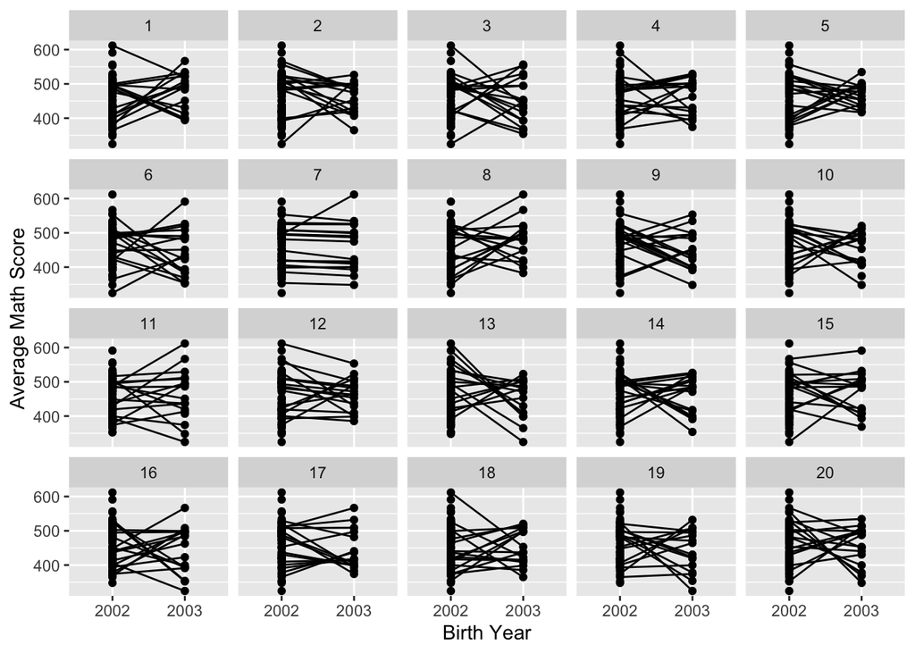

```r
library(nullabor)
set.seed(2020)

df <- pisa2018 %>%
   filter(!is.na(ST003D03T)) %>%
   mutate(birth_year = as.character(ST003D03T)) %>%
   group_by(CNT, birth_year) %>%
   summarise(math_score = weighted.mean(PV1MATH, SENWT, na.rm = T)) %>%
   filter(birth_year != 2001 ) %>%   # since only one country
   ungroup()


lineup(null_permute("math_score"), df) %>%
   ggplot(aes(birth_year, math_score, group = CNT)) +
   geom_point() +
   geom_line() +
   facet_wrap(~.sample) +
   labs(x = "Birth Year", y = "Average Math Score")
```